# Oligo analysis script v2 (adapted for umierrorcorrect)

Stefan Filges

2022-09-21

## Setup

### User-defined variables

Set the working directory “main” and import plotting functions from the helper functions file.

**NOTE!** For this to work you need to specify the location of the ‘helper_functions_oligo.R’ scripts. It contains a number of functions that will be used throughout this analysis.

```r
# Should individual files with VAF be printed?
print.individual.files = FALSE

# Select consensus threshold to use for analysis
consensus_cutoff <- 10

# Create table of sample directory paths
# First define the directory containing UMIErrrorCorrect output files
sample_dir = '/Users/stefan/Documents/GitHub/OligoAnalysis/data/umierrorcorrect'

# Load helper functions, change location if needed
source('/Users/stefan/Documents/GitHub/OligoAnalysis/src/helper_functions_oligo.R')
```

### Loading packages

We begin by importing the required packages, and if necessary installing them.

```r
# CRAN packages to be installed with checkPackages
packages <- c('tidyverse', 'gridExtra', 'RColorBrewer', 'stringr', 'tis')

# Check and if needed install CRAN packages
checkPackages(requiredPackages = packages)

# If needed, install BiocManager for downloading packages from Bioconductor
if (!require("BiocManager", quietly = TRUE)){
  install.packages("BiocManager")
}

# If needed, install Rsamtools from Bioconductor
if (!require("Rsamtools", quietly = TRUE)){
  BiocManager::install("Rsamtools")
}

# Load packages
library(tidyverse)
library(Rsamtools)
library(EnvStats)
library(Hmisc)
library(ggpmisc)
```

### Importing data

#### Setting up the file structure

We then load the paths to the UMIErrorCorrect output folders into the samplePaths variable and create a data frame “sampleNames”, that contains the sample metadata based on the folder name.

**NOTE!**

```
Sample folders generated with UMIErrorCorrect need to have a specific format or else
the code below needs to be changed for the script to run. Each folder needs to contain
the following information the the same order, separated by underscores:

Manufacturer_InsertType_Purification_Batch_Replicate
```

One relatively easy way to get this format is to use it on the sample sheet used for demultiplexing the sequencing run. Demultiplexed fastq files will append additional information such as Lane and Read such that the final fastq would look somewhat like

‘Manufacturer_InsertType_Purification_Batch_Replicate_L001_R1_001.fastq.gz’

Use a shell script or other to batch process multiple fastqs at once using UMIErrorCorrect and use that same script to trim ’_L001_R1_001.fastq.gz’ from the output folder names, thus resulting in intended format.

At this stage, also define the “consensus_cutoff” variable which sets the minimum UMI family size to keep. Somewhere between 3 and 10 will usually be appropriate.

Lastly, a new tibble is initialized into which all consensus table will be loaded in the next step.

```r
# Get full paths for each sample folder
samplePaths <- list.dirs(
  path = sample_dir,
  recursive = FALSE
)

# Create data frame with sample metadata by listing all samples in the previously
# defined samplePaths
sampleNames <- list.dirs(
  path = sample_dir,
  recursive = FALSE,
  full.names = FALSE
)

# Split the sample names into columns by the delimiter '_'
sampleNames <- as.data.frame(do.call(rbind, strsplit(sampleNames, '_')))

# set column names of meta data
colnames(sampleNames) <- c('Manufacturer', 'InsertType', 'Purification', 'Batch', 'Replicate')

# add sample paths to the data frame
sampleNames$File <- samplePaths

# print first few rows and verify that information is correct
print(head(sampleNames))
```

```
##   Manufacturer InsertType Purification Batch Replicate
## 1           bs        fwd        dHPLC    b1         1
## 2           bs        fwd        dHPLC    b1         2
## 3           bs        fwd        dHPLC    b1         3
## 4     eurofins        fwd     extremer    b1         1
## 5     eurofins        fwd     extremer    b1         2
## 6     eurofins        fwd     extremer    b1         3
##                                                                                           File
## 1          /Users/stefan/Documents/GitHub/OligoAnalysis/data/umierrorcorrect/bs_fwd_dHPLC_b1_1
## 2          /Users/stefan/Documents/GitHub/OligoAnalysis/data/umierrorcorrect/bs_fwd_dHPLC_b1_2
## 3          /Users/stefan/Documents/GitHub/OligoAnalysis/data/umierrorcorrect/bs_fwd_dHPLC_b1_3
## 4 /Users/stefan/Documents/GitHub/OligoAnalysis/data/umierrorcorrect/eurofins_fwd_extremer_b1_1
## 5 /Users/stefan/Documents/GitHub/OligoAnalysis/data/umierrorcorrect/eurofins_fwd_extremer_b1_2
## 6 /Users/stefan/Documents/GitHub/OligoAnalysis/data/umierrorcorrect/eurofins_fwd_extremer_b1_3
```

#### Import files

For each sample the cons files are loaded and metadata is added to the consensus table for filtering later on. The metadata is derived from the folder name and used for filtering of samples downstream.

If necessary, re-code factor variables for clarity or better plotting, e.g. shortening names. This part may *not* always be necessary if files are named consistently from the start. If no factors need to be re-coded, either delete this code block or set eval=FALSE.

### Remove reference allele counts

Filter positions based on the reference sequence for this sample. This is meant to exclude primer sequences and samples with a different reference sequence.

At the moment this will not work for samples containing multiple different primers pairs or samples with variable insert length. That is, all samples need to:

```r
cons.table.filtered <- cons.table %>%
  dplyr::filter(
    InsertType %in% c('Insert_1', 'Insert_2'), # Exclude genomic reference
    Position >= 19,        # consider only sequences after forward primer
    Position <= 80         # consider only sequenced before reverse primer
  )

cons.table.filtered <- cons.table

print(dim(cons.table))
```

```
## [1] 8060   22
```

```r
print(dim(cons.table.filtered))
```

```
## [1] 8060   22
```

Set all reference allele counts to 0, so that only *non-reference* counts remain for each position.

```r
# Set reference counts to 0
# If processing many samples at once many samples, for the for loop will be slow
for(j in 1:nrow(cons.table.filtered)) {
  row <- cons.table.filtered[j,]
  if( row$Reference == 'A' ) {
    cons.table.filtered[j,]$A <- 0
  }
  else if( row$Reference == 'C' ) {
    cons.table.filtered[j,]$C <- 0
  }
  else if( row$Reference == 'G' ) {
    cons.table.filtered[j,]$G <- 0
  }
  else if( row$Reference == 'T' ) {
    cons.table.filtered[j,]$T <- 0
  }
}
```

## Mean deletions & substitutions error

Calculate the mean deletion and substitution error grouped by Manufacturer, InsertType, Purification, Batch and Consensus group size.

```r
print(
  head(cons.table.filtered)
)
```

```
##                        Sample Name            Contig Position     Name
## 1 bs_fwd_dHPLC_b1_1_S7_L001_R1_001 TP1_synth_forward       19 Insert_1
## 2 bs_fwd_dHPLC_b1_1_S7_L001_R1_001 TP1_synth_forward       19 Insert_1
## 3 bs_fwd_dHPLC_b1_1_S7_L001_R1_001 TP1_synth_forward       20 Insert_1
## 4 bs_fwd_dHPLC_b1_1_S7_L001_R1_001 TP1_synth_forward       20 Insert_1
## 5 bs_fwd_dHPLC_b1_1_S7_L001_R1_001 TP1_synth_forward       21 Insert_1
## 6 bs_fwd_dHPLC_b1_1_S7_L001_R1_001 TP1_synth_forward       21 Insert_1
##   Reference  A C G   T   I    D N Coverage Consensus group size
## 1         A  0 2 4 266 184 2441 2   550711                    0
## 2         A  0 0 0   1   1   42 0     6988                   10
## 3         T 71 4 2   0  96 1447 3   552126                    0
## 4         T  1 0 0   0   1   16 0     7002                   10
## 5         A  0 1 2  11 213 1590 2   551772                    0
## 6         A  0 0 0   0   6   19 0     6998                   10
##   Max Non-ref Allele Count Max Non-ref Allele Frequency Max Non-ref Allele
## 1                     2441                  0.004432452                  D
## 2                       42                  0.006010303                  D
## 3                     1447                  0.002620779                  D
## 4                       16                  0.002285061                  D
## 5                     1590                  0.002881625                  D
## 6                       19                  0.002715061                  D
##   Manufacturer InsertType Purification Batch Replicate
## 1           BS   Insert_1        dHPLC    b1         1
## 2           BS   Insert_1        dHPLC    b1         1
## 3           BS   Insert_1        dHPLC    b1         1
## 4           BS   Insert_1        dHPLC    b1         1
## 5           BS   Insert_1        dHPLC    b1         1
## 6           BS   Insert_1        dHPLC    b1         1
```

```r
del.count <- cons.table.filtered %>%
  group_by(Manufacturer, InsertType, Purification, Batch, `Consensus group size`) %>%
  summarise(del_error = 100*mean(D)/mean(Coverage))
```

```
## 'Purification', 'Batch'. You can override using the `.groups` argument.
```

```r
print(
  head(del.count)
)
```

```
##   Manufacturer InsertType Purification Batch Consensus group size  del_error
## 1           BS   Insert_1        dHPLC    b1                    0 0.16693834
## 2           BS   Insert_1        dHPLC    b1                   10 0.15202751
## 3           EF   Insert_1     extremer    b1                    0 0.03439440
## 4           EF   Insert_1     extremer    b1                   10 0.03200380
## 5           EF   Insert_1         PAGE    b1                    0 0.03611345
## 6           EF   Insert_1         PAGE    b1                   10 0.03354662
```

```r
subs.count <- cons.table.filtered %>%
  group_by(Manufacturer, InsertType, Purification, Batch, `Consensus group size`) %>%
  summarise(subs_error = 100*mean(A+C+G+T)/mean(Coverage))
```

```
## 'Purification', 'Batch'. You can override using the `.groups` argument.
```

```r
print(
  head(subs.count)
)
```

```
##   Manufacturer InsertType Purification Batch Consensus group size subs_error
## 1           BS   Insert_1        dHPLC    b1                    0 0.07378919
## 2           BS   Insert_1        dHPLC    b1                   10 0.04522389
## 3           EF   Insert_1     extremer    b1                    0 0.20438595
## 4           EF   Insert_1     extremer    b1                   10 0.11498139
## 5           EF   Insert_1         PAGE    b1                    0 0.04806722
## 6           EF   Insert_1         PAGE    b1                   10 0.02999462
```

## SiMSen-Seq error correction (raw versus consensus reads)

Alternatively, plot using facet_wrap (code not written).

### Insert variant 1

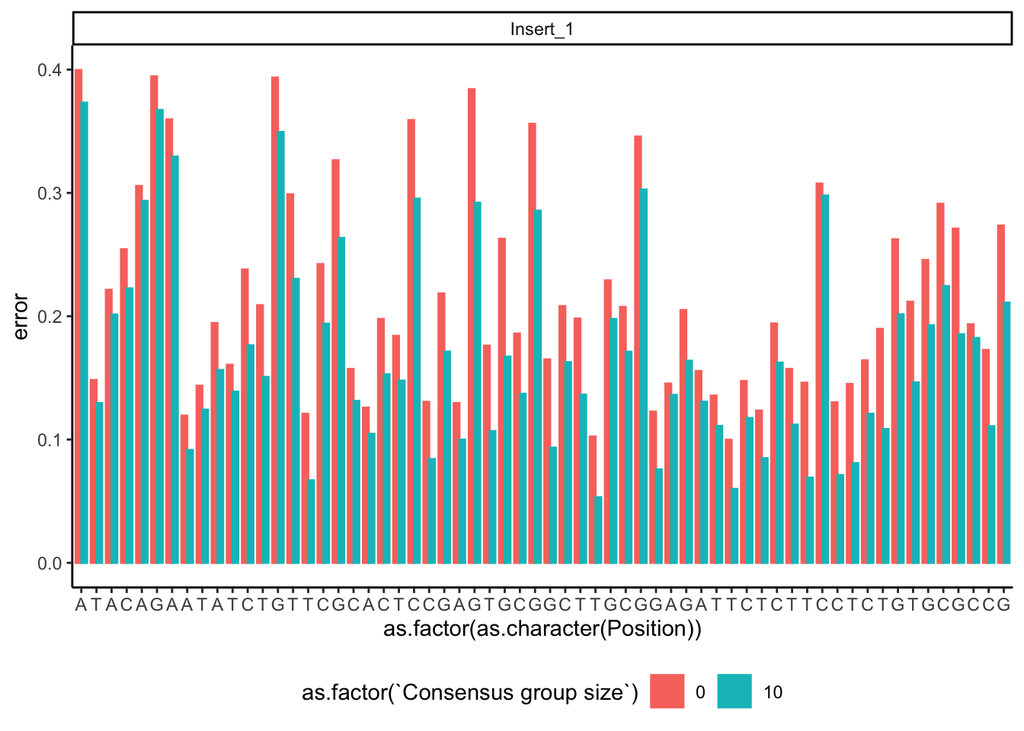

```r
#----------------- // Insert 1 //---------------------
# Get data for insert type "Insert_1" and remove control samples (=cell line)
amplicon.plot.data1 <- cons.table.filtered %>%
    dplyr::mutate(
      total_error = 100*(A+C+G+T+D+I)/Coverage
    ) %>%
    dplyr::filter(Manufacturer != "control", InsertType == "Insert_1") %>%
    tidyr::unite('Type', Manufacturer, Purification, sep = ' ') %>%
    dplyr::group_by(Position, InsertType, Reference, `Consensus group size`) %>%
    dplyr::summarise(
      total_error = mean(total_error)
    ) %>%
  tidyr::gather("error_type", "error", -c("Position", "InsertType", "Reference", `Consensus group size`))

# Get x-axis labels
labels1 <- amplicon.plot.data1 %>%
  dplyr::ungroup() %>%
  dplyr::distinct(Position, Reference)

# Generate plot for Insert_1
error_plot_1 <- ggplot(
  data = amplicon.plot.data1,
  mapping = aes(
    x = as.factor(as.character(Position)),
    y = error,
    fill = as.factor(`Consensus group size`),
    color = as.factor(`Consensus group size`))
  ) +
  geom_bar(stat = 'identity', position = 'dodge', width = 0.75) +
  scale_x_discrete(breaks=labels1$Position, labels=labels1$Reference) +
  theme_classic() +
  theme(
    legend.position = 'bottom'
  ) +
  facet_wrap(InsertType ~ ., scales = 'free_x', nrow = 1)

# Draw plot
error_plot_1
```

```r
# Save plot to pdf
#ggsave(filename = 'Figure_1c_insert_1.pdf', plot = error_plot_1, device = 'pdf')
```

### Insert variant 2

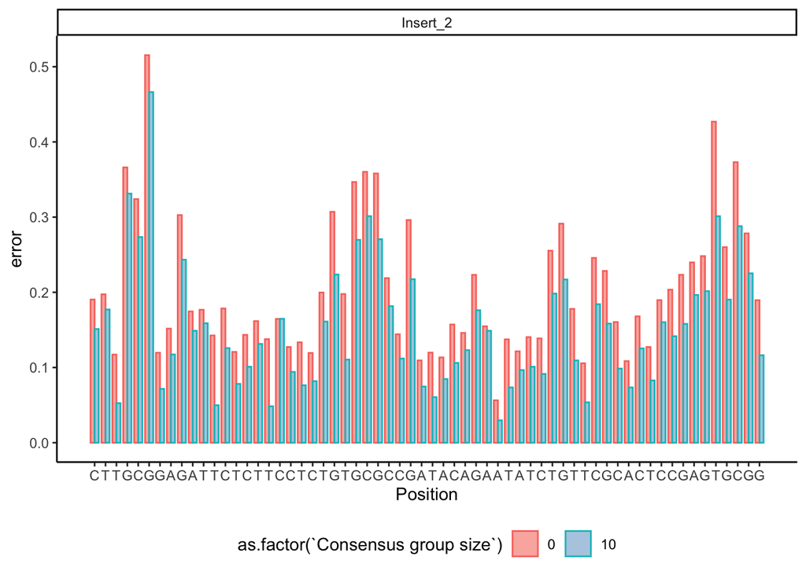

```r
#----------------- // Insert 2 //---------------------
# Get data for insert type "Insert_2" and remove control samples (=cell line)
amplicon.plot.data2 <- cons.table.filtered %>%
    dplyr::mutate(
      total_error = 100*(A+C+G+T+D+I)/Coverage
    ) %>%
    dplyr::filter(Manufacturer != "control", InsertType == "Insert_2") %>%
    tidyr::unite('Type', Manufacturer, Purification, sep = ' ') %>%
    dplyr::group_by(Position, InsertType, Reference, `Consensus group size`) %>%
    dplyr::summarise(
      total_error = mean(total_error)
    ) %>%
  tidyr::gather("error_type", "error", -c("Position", "InsertType", "Reference", `Consensus group size`))

# Get x-axis labels
labels2 <- amplicon.plot.data2 %>%
  dplyr::ungroup() %>%
  dplyr::distinct(Position, Reference)

# Generate plot for Insert_2
error_plot_2 <- ggplot(
  data = amplicon.plot.data2,
  mapping = aes(
    x = Position,
    y = error,
    fill = as.factor(`Consensus group size`),
    color = as.factor(`Consensus group size`))
  ) +
  geom_bar(stat = 'identity', position = 'dodge', width = 0.75) +
  scale_x_continuous(breaks=labels2$Position, labels=labels2$Reference) +
  theme_classic() +
  theme(
    legend.position = 'bottom'
  ) +
  facet_wrap(InsertType ~ ., scales = 'free_x', nrow = 1) +
  scale_fill_brewer(palette = "Pastel1")

# Draw plot
error_plot_2
```

```r
# Save plot to pdf
#ggsave(filename = 'Figure_1c_insert_2.pdf', plot = error_plot_2, device = 'pdf')
```

## Quantifying deletions in consensus reads

We load the consensus reads and meta data for each sample and then count the number of deletions in each consensus read. For each sample we then determine the fraction of reads containing 1 to 7 or more deleted bases. Note, that the deletions do not have to be consecutive, but can be spread throughout the read.

First, we load the bam file containing the consensus reads generated by UMIErrorCorrect. The following information is then extracted:

- UMI/barcode
- UMI family size

**NOTE!** Processing many alignment files will take a considerable amount of time! Expect roughly 2 min per sample.

This code section will be skipped if output files already exist.

```r
#---------------------// Reference sequences //---------------------------------
primer_1 ="GTGGTGAGGCTCCCCTTT"
primer_2 = "CAAAGCTGTTCCGTCCCAGT"

forward_insert = "ATACAGAATATCTGTTCGCACTCCGAGTGCGGCTTGCGGAGATTCTCTTCCTCTGTGCGCCG"
reverse_insert = "CTTGCGGAGATTCTCTTCCTCTGTGCGCCGATACAGAATATCTGTTCGCACTCCGAGTGCGG"
#-------------------------------------------------------------------------------

# Because execution of this code block can take some time, check if the the  output
# from this block (df and df2) already exist, if so, skip this block.
df_exists <- file.exists(paste(sample_dir,'/df.csv', sep = ''))
df2_exists <- file.exists(paste(sample_dir,'/df2.csv', sep = ''))

if(!(df_exists && df2_exists)){

  # Initialize output tables
  df = data.frame()
  df2 = data.frame()

  #How many samples were found?
  print(paste("Found ", nrow(sampleNames), " samples.", sep = ''))

  for(i in 1:nrow(sampleNames)){

    print(paste("Processing sample ", i, " out of " , nrow(sampleNames), ".", sep = ''))

    out.file <- ''

    row <- sampleNames[i,]
    row2 <- sampleNames[i,]
    dir <- sampleNames$File[i]

    # Get file(s) ending with '.consensus_reads.bam$', there should only be one!
    bamPath <- list.files(
      path = dir,
      pattern = '.consensus_reads.bam$',
      full.names = TRUE
    )

    # Load consensus reads bam file.
    # TODO This will break if multiple files are found in the step above
    bamFile <- Rsamtools::BamFile(file = bamPath)

    # Import binary ‘BAM’ files into a list structure
    alignment <- Rsamtools::scanBam(bamFile)[[1]]
    length <- length(alignment$qname)

    # Initialize empty results data frame
    file = data.frame(
      position=character(),
      barcode=character(),
      counts=numeric(),
      sequence=character(),
      cigar=character()
      )

    # Iterate through bam file. This can be very slow!
    for(i in 1:length){
      # get chromosome coordinates
      pos <- alignment$pos[i]
      chrom <- alignment$rname[i]
      coord <- paste(chrom,':',pos,sep='')

      # get read sequence
      sequence <- as.character(alignment$seq[i])

      # get header containing barcodes and counts
      header <- alignment$qname[i]

      # split header
      header <- str_split(header, "_")

      # extract barcode from header
      barcode <- header[[1]][4]

      # get CIGAR string
      cigar <- alignment$cigar[i]

      # extract UMI family size from header and convert to numeric
      count <- header[[1]][5]
      if(!count %in% letters[seq( from = 1, to = 20 )]){
        # TODO this checks if a read is split into multiple chunks labeled a,b,c
        # e.g. for paired-end data, these reads are ignored for now!!
        count <- as.numeric(gsub(".*=","",count))

        # save only UMI families with >= threshold reads
        if(count >= consensus_cutoff){
          nrow <- nrow(file)
          file[nrow+1,] <- c(coord, barcode, count, sequence, cigar)
        }
      }
    }

    # Get length of read
    file$nchar <- nchar(file$sequence)

    # This returns the total number of deleted bases for that string
    # Examples:
    # ACTG-DD-AT gives 2
    # ATG-D gives 1
    # A-DDD-TCGA-DD-TGC gives 5
    file$n_D <- processCigar(file$cigar)

    # For each sample calculate the fraction of reads that contain 0,1,2,...,6 or
    # 7 or more deleted bases
    nreads <- nrow(file)

    row$`0` <- 100*(nrow(file[file$n_D == 0,])/nreads)
    row$`1` <- 100*(nrow(file[file$n_D == 1,])/nreads)
    row$`2` <- 100*(nrow(file[file$n_D == 2,])/nreads)
    row$`3` <- 100*(nrow(file[file$n_D == 3,])/nreads)
    row$`4` <- 100*(nrow(file[file$n_D == 4,])/nreads)
    row$`5` <- 100*(nrow(file[file$n_D == 5,])/nreads)
    row$`6` <- 100*(nrow(file[file$n_D == 6,])/nreads)
    row$`>7` <- 100*(nrow(file[file$n_D >= 7,])/nreads)

    # Here we compute the number of times that 2,3,4 or 5 bases were deleted
    # consecutively in each read, i.e. ACT-DD-ACT counts, but AC-D-AT-D-CT does
    # not even though both have 2 deleted bases.
    # TODO this does not take into account other situations, such as 6 consecutively deleted bases
    file$n_D2 <- stringr::str_count(string = file$cigar, pattern = '2D')
    file$n_D3 <- stringr::str_count(string = file$cigar, pattern = '3D')
    file$n_D4 <- stringr::str_count(string = file$cigar, pattern = '4D')
    file$n_D5 <- stringr::str_count(string = file$cigar, pattern = '5D')

    # Count reads with exactly 2 deleted bases, where _D == 2, irrespective of
    # whether they occurred together DD or separately ACT-D-ACT-D-ACT, both are n_D = 2.
    row2$n_two_errors <- nrow(file %>% dplyr::filter(n_D == 2))

    # Count reads where exactly 2 bases were deleted AND these occurred consecutively
    row2$n_two_errors_together <- nrow(file %>% dplyr::filter(n_D == 2, n_D2 == 1))

    # Repeat for 3 bases
    row2$n_three_errors <- nrow(file %>% dplyr::filter(n_D == 3))
    row2$n_three_errors_together <- nrow(file %>% dplyr::filter(n_D == 3, n_D3 == 1))

    # Repeat for 4 bases
    row2$n_four_errors <- nrow(file %>% dplyr::filter(n_D == 4))
    row2$n_four_errors_together <- nrow(file %>% dplyr::filter(n_D == 4, n_D4 == 1))

    df <- rbind(df,row)
    df2 <- rbind(df2,row2)
  }
  write_csv(x = df, file = 'data/df.csv')
  write_csv(x = df2, file = 'data/df2.csv')
} else{
  # Else, if output exists, import them
  df = readr::read_csv(paste(sample_dir,'/df.csv', sep = ''))
  df2 = readr::read_csv(paste(sample_dir,'/df2.csv', sep = ''))
}
```

Changing variable names as before. Can be omitted using eval=FALSE if needed.

```r
# Change names of factor variables
df$Manufacturer <- forcats::fct_recode(
  df$Manufacturer,
  IDT = 'idt',
  BS = 'bs',
  SA = 'sig',
  EF = 'eurofins'
)
df$Purification <- forcats::fct_recode(
  df$Purification,
  desalted = 'des'
)
df$InsertType <- forcats::fct_recode(
  df$InsertType,
  Insert_1 = 'fwd',
  Insert_2 = 'rev'
)

#write.csv(
#  x = df,
#  file = paste(Sys.Date(),'consensus_read_deletions_counts.csv', sep = '_')
#)

# Change names of factor variables
df2$Manufacturer <- forcats::fct_recode(
  df2$Manufacturer,
  IDT = 'idt',
  BS = 'bs',
  SA = 'sig',
  EF = 'eurofins'
)
df2$Purification <- forcats::fct_recode(
  df2$Purification,
  desalted = 'des'
)
df2$InsertType <- forcats::fct_recode(
  df2$InsertType,
  Insert_1 = 'fwd',
  Insert_2 = 'rev'
)
```

### Deletion boxplots

If multiple bases are deleted, calculated the fraction of deletions that occurred together. For example data_2 calculates the situation for 2 deleted bases: If n_two_errors is non zero there are 2 deleted bases in that read, then calculate the fraction n_two_errors_together/n_two_errors, otherwise the value is 0. The same calculation is performed for 3 and 4 deletions, respectively.

```r
data_2 <- df2 %>%
  dplyr::mutate(ratio = if_else(n_two_errors != 0, n_two_errors_together/n_two_errors, 0)) %>%
  tidyr::unite("Type", Manufacturer, Purification, InsertType, sep = " ") %>%
  dplyr::group_by(Type) %>%
  dplyr::summarise(mean = mean(ratio), sd = sd(ratio))


data_3 <- df2 %>%
  dplyr::mutate(ratio = if_else(n_three_errors != 0, n_three_errors_together/n_three_errors, 0)) %>%
  tidyr::unite("Type", Manufacturer, Purification, InsertType, sep = " ") %>%
  dplyr::group_by(Type) %>%
  dplyr::summarise(mean = mean(ratio), sd = sd(ratio))


data_4 <- df2 %>%
  dplyr::mutate(ratio = if_else(n_four_errors != 0, n_four_errors_together/n_four_errors, 0)) %>%
  tidyr::unite("Type", Manufacturer, Purification, InsertType, sep = " ") %>%
  dplyr::group_by(Type) %>%
  dplyr::summarise(mean = mean(ratio), sd = sd(ratio))


data_2["Del"] <- "2"
data_3["Del"] <- "3"
data_4["Del"] <- "4"

data <- rbind(data_2,data_3,data_4)
```

Now we plot this data as boxplots

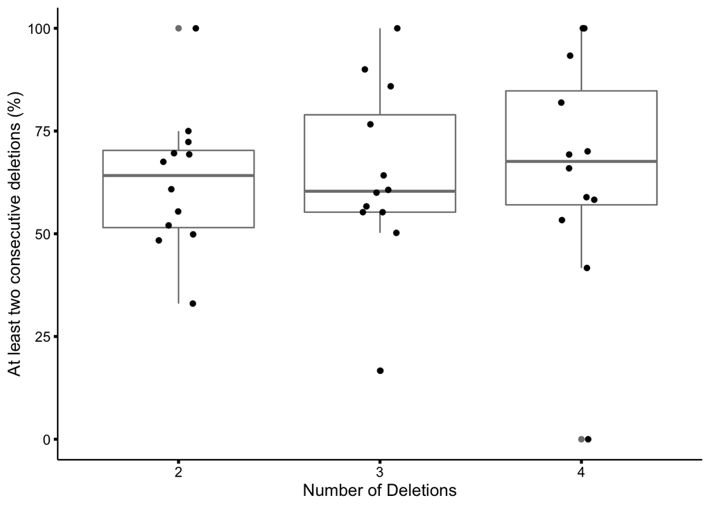

```r
boxplot_deletions <- ggplot2::ggplot(
  data = data,
  mapping = aes(
    x = as.factor(Del),
    y = 100*(mean)
    )
  ) +
  geom_boxplot(colour = "grey50") +
  geom_jitter(
      width = 0.1
    ) +
  xlab(label = "Number of Deletions") +
  ylab(label = "At least two consecutive deletions (%)") +
  theme_minimal() +
  theme(
    axis.title = element_text(size = 12,colour = "black"),
    axis.text = element_text(size = 10,colour = "black"),
    axis.ticks = element_line(size = 1),
    panel.border = element_blank(),
    panel.grid.major = element_blank(),
    panel.grid.minor = element_blank(),
    axis.line = element_line(colour = 'black'),
    legend.position = "bottom"
    )

# add comment
boxplot_deletions
```

```r
#ggsave(filename = 'boxplot_deletions.pdf', plot = boxplot_deletions, device = 'pdf')
```

We can also plot deletions as a barplot

```r
df3 <- df %>%
  tidyr::unite("Type", Manufacturer, Purification, InsertType, sep = " ") %>%
  dplyr::group_by(Type) %>%
  dplyr::summarise(mean = mean(`0`))


order <- df3[order(df3$mean, decreasing = TRUE),]$Type

data$Type <- as.factor(data$Type)
data$Type <- forcats::fct_relevel(data$Type, c('IDT gblocks Insert_1','IDT gblocks Insert_2', 'control MCF7 Insert_1'), after = Inf)
```

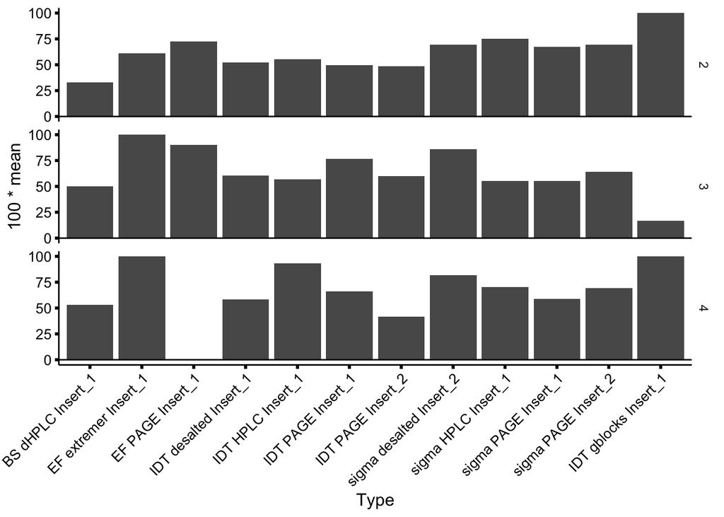

```r
#data$Type <- fct_relevel(data$Type, order)

barplot_deletions <- ggplot2::ggplot(
  data = data,
  mapping = aes(
    x = Type,
    y = 100*mean
    )
  ) +
  facet_wrap(Del ~ ., ncol = 1, strip.position="right") +
  geom_bar(stat = "identity") +
  geom_hline(yintercept = 0) +
  theme_minimal() +
  theme(
    axis.title = element_text(size = 12,colour = "black"),
    axis.text = element_text(size = 10,colour = "black"),
    axis.text.x = element_text(angle = 45, hjust = 1),
    axis.ticks = element_line(size = 1),
    panel.border = element_blank(),
    panel.grid.major = element_blank(),
    panel.grid.minor = element_blank(),
    axis.line = element_line(colour = 'black'),
    legend.position = "bottom"
    )


barplot_deletions
```

```r
#ggsave(filename = 'barplot_deletions.pdf', plot = barplot_deletions, device = 'pdf')
```

### Figure 1b

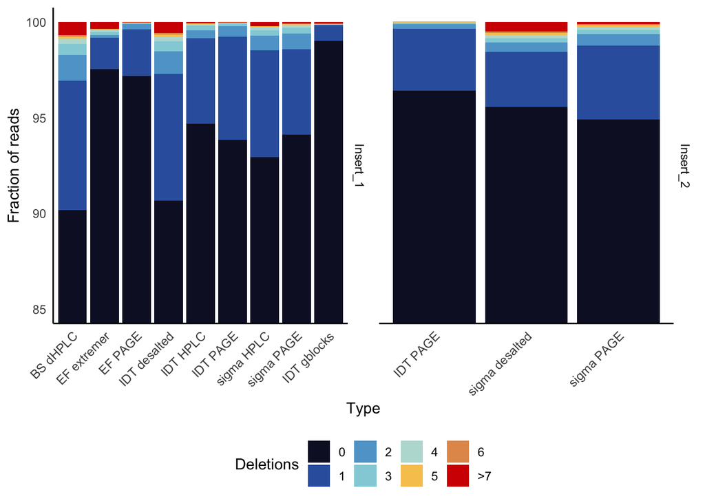

```r
plot_data <- df %>%
  tidyr::gather(
    key = 'Deletions',
    value = 'Fraction of reads',
    -c(Manufacturer,InsertType,Purification,Batch,Replicate,File)
  ) %>%
  dplyr::filter(InsertType != 'gDNA') %>%
  tidyr::unite(col = 'Type', Manufacturer, Purification, sep = ' ') %>%
  dplyr::group_by(Type, InsertType, Deletions) %>%
  dplyr::summarise(`Fraction of reads` = mean(`Fraction of reads`))
plot_data$Deletions <- forcats::fct_relevel(plot_data$Deletions, '>7', after = Inf)
plot_data$Type <- forcats::fct_relevel(plot_data$Type, c('IDT gblocks', 'control MCF7'), after = Inf)
# Custom colour palette: blue -> green -> red
plot_colours <- c('#11122F', '#3462AB', '#5EA4D1', '#92D1DA', '#B9DDD5', '#F7C75D', '#E3985B', '#D31D00')

figure1b <- ggplot2::ggplot(
  data = plot_data,
  mapping = aes(
    x = Type,
    y = `Fraction of reads`,
    fill = Deletions
    )
  ) +
  geom_bar(position=position_stack(reverse = TRUE) , stat = 'identity') +
  facet_wrap(InsertType~., scales = 'free_x', strip.position = 'right') +
  theme_minimal() +
  theme(
    axis.text.x = element_text(
      hjust = 1,
      angle = 45,
      size = 9
    ),
    panel.border = element_blank(),
    panel.grid.major = element_blank(),
    panel.grid.minor = element_blank(),
    axis.line = element_line(colour = 'black'),
    legend.position = "bottom"
    ) +
  #scale_fill_brewer(palette = 'Spectral',direction = -1) +
  scale_fill_manual(values = plot_colours) +
  coord_cartesian(ylim = c(85,NA))

figure1b
```

```r
#ggsave(filename = 'Figure_1b.pdf', plot = figure1b, device = 'pdf')
```

## Wilcoxon tests

### Insert Type 1

```
##                          BS dHPLC Insert_1 b1 EF extremer Insert_1 b1
## EF extremer Insert_1 b1          1.397412e-07                      NA
## EF PAGE Insert_1 b1              1.000000e+00            1.000000e+00
## IDT desalted Insert_1 b1         1.000000e+00            2.250710e-04
## IDT desalted Insert_1 b2         2.683158e-04            3.993714e-18
## IDT desalted Insert_1 b3         2.658402e-05            1.000000e+00
## IDT gblocks Insert_1 b1          1.687469e-48            8.510231e-17
## IDT HPLC Insert_1 b1             1.031943e-07            1.000000e+00
## IDT PAGE Insert_1 b1             7.294376e-04            7.058222e-01
## IDT PAGE Insert_1 b2             1.603223e-16            1.000000e+00
## IDT PAGE Insert_1 b3             3.954949e-07            1.000000e+00
## SA HPLC Insert_1 b1              1.000000e+00            1.806871e-03
## SA PAGE Insert_1 b1              3.788468e-03            4.967466e-17
## SA PAGE Insert_1 b2              1.220323e-02            1.000000e+00
## SA PAGE Insert_1 b3              1.168790e-06            1.000000e+00
##                          EF PAGE Insert_1 b1 IDT desalted Insert_1 b1
## EF extremer Insert_1 b1                   NA                       NA
## EF PAGE Insert_1 b1                       NA                       NA
## IDT desalted Insert_1 b1        1.000000e+00                       NA
## IDT desalted Insert_1 b2        8.451558e-05             1.375839e-11
## IDT desalted Insert_1 b3        1.000000e+00             2.419658e-02
## IDT gblocks Insert_1 b1         6.296462e-20             4.871742e-54
## IDT HPLC Insert_1 b1            1.000000e+00             7.298026e-05
## IDT PAGE Insert_1 b1            1.000000e+00             1.879825e-02
## IDT PAGE Insert_1 b2            4.981300e-02             5.529363e-15
## IDT PAGE Insert_1 b3            1.000000e+00             1.371641e-04
## SA HPLC Insert_1 b1             1.000000e+00             1.000000e+00
## SA PAGE Insert_1 b1             2.269189e-04             2.882037e-09
## SA PAGE Insert_1 b2             1.000000e+00             1.000000e+00
## SA PAGE Insert_1 b3             1.000000e+00             7.783587e-04
##                          IDT desalted Insert_1 b2 IDT desalted Insert_1 b3
## EF extremer Insert_1 b1                        NA                       NA
## EF PAGE Insert_1 b1                            NA                       NA
## IDT desalted Insert_1 b1                       NA                       NA
## IDT desalted Insert_1 b2                       NA                       NA
## IDT desalted Insert_1 b3             3.925352e-18                       NA
## IDT gblocks Insert_1 b1              8.407216e-51             1.225292e-29
## IDT HPLC Insert_1 b1                 9.697594e-19             1.000000e+00
## IDT PAGE Insert_1 b1                 2.512013e-12             1.000000e+00
## IDT PAGE Insert_1 b2                 4.061244e-28             1.089622e-01
```

[output cut: 50 more lines]

```
##                          SA PAGE Insert_1 b1 SA PAGE Insert_1 b2
## EF extremer Insert_1 b1                   NA                  NA
## EF PAGE Insert_1 b1                       NA                  NA
## IDT desalted Insert_1 b1                  NA                  NA
## IDT desalted Insert_1 b2                  NA                  NA
## IDT desalted Insert_1 b3                  NA                  NA
## IDT gblocks Insert_1 b1                   NA                  NA
## IDT HPLC Insert_1 b1                      NA                  NA
## IDT PAGE Insert_1 b1                      NA                  NA
## IDT PAGE Insert_1 b2                      NA                  NA
## IDT PAGE Insert_1 b3                      NA                  NA
## SA HPLC Insert_1 b1                       NA                  NA
## SA PAGE Insert_1 b1                       NA                  NA
## SA PAGE Insert_1 b2             6.065242e-11                  NA
## SA PAGE Insert_1 b3             1.409937e-16                   1
```

### Insert Type 2

```
##                         IDT PAGE Insert_2 b1 IDT PAGE Insert_2 b2
## IDT PAGE Insert_2 b2            1.000000e+00                   NA
## SA desalted Insert_2 b1         1.000000e+00         1.000000e+00
## SA desalted Insert_2 b2         7.099450e-13         9.237728e-08
## SA desalted Insert_2 b3         1.370795e-11         3.087864e-08
## SA PAGE Insert_2 b1             2.817626e-06         1.433349e-04
## SA PAGE Insert_2 b2             6.055141e-11         1.260745e-07
## SA PAGE Insert_2 b3             1.363039e-18         6.799253e-14
##                         SA desalted Insert_2 b1 SA desalted Insert_2 b2
## IDT PAGE Insert_2 b2                         NA                      NA
## SA desalted Insert_2 b1                      NA                      NA
## SA desalted Insert_2 b2            2.334497e-09                      NA
## SA desalted Insert_2 b3            4.463951e-09              1.00000000
## SA PAGE Insert_2 b1                5.700641e-05              1.00000000
## SA PAGE Insert_2 b2                6.165861e-09              1.00000000
## SA PAGE Insert_2 b3                1.467270e-14              0.04482284
##                         SA desalted Insert_2 b3 SA PAGE Insert_2 b1
## IDT PAGE Insert_2 b2                         NA                  NA
## SA desalted Insert_2 b1                      NA                  NA
## SA desalted Insert_2 b2                      NA                  NA
## SA desalted Insert_2 b3                      NA                  NA
## SA PAGE Insert_2 b1                   1.0000000                  NA
## SA PAGE Insert_2 b2                   1.0000000          1.00000000
## SA PAGE Insert_2 b3                   0.4294328          0.06257646
##                         SA PAGE Insert_2 b2
## IDT PAGE Insert_2 b2                     NA
## SA desalted Insert_2 b1                  NA
## SA desalted Insert_2 b2                  NA
## SA desalted Insert_2 b3                  NA
## SA PAGE Insert_2 b1                      NA
## SA PAGE Insert_2 b2                      NA
## SA PAGE Insert_2 b3                       1
```

## Dinucleotide combinations

```
##
##  Welch Two Sample t-test
##
## data:  A_error and C_error
## t = 1.0772, df = 207.8, p-value = 0.2826
## alternative hypothesis: true difference in means is not equal to 0
## 95 percent confidence interval:
##  -0.02558564  0.08722680
## sample estimates:
## mean of x mean of y
## 0.1695784 0.1387578
```

```
##
##  Welch Two Sample t-test
##
## data:  A_error and G_error
## t = 2.435, df = 154.83, p-value = 0.01603
## alternative hypothesis: true difference in means is not equal to 0
## 95 percent confidence interval:
##  0.01139507 0.10934337
## sample estimates:
## mean of x mean of y
## 0.1695784 0.1092092
```

```
##
##  Welch Two Sample t-test
##
## data:  T_error and G_error
## t = 2.8828, df = 173.18, p-value = 0.004441
## alternative hypothesis: true difference in means is not equal to 0
## 95 percent confidence interval:
##  0.02236848 0.11950163
## sample estimates:
## mean of x mean of y
## 0.1801442 0.1092092
```

```
##
##  Welch Two Sample t-test
##
## data:  T_error and C_error
## t = 1.4547, df = 225.79, p-value = 0.1471
## alternative hypothesis: true difference in means is not equal to 0
## 95 percent confidence interval:
##  -0.01467652  0.09744935
## sample estimates:
## mean of x mean of y
## 0.1801442 0.1387578
```

```
##
##  Welch Two Sample t-test
##
## data:  C_error and G_error
## t = 1.3294, df = 209.69, p-value = 0.1851
## alternative hypothesis: true difference in means is not equal to 0
## 95 percent confidence interval:
##  -0.01426723  0.07336451
## sample estimates:
## mean of x mean of y
## 0.1387578 0.1092092
```

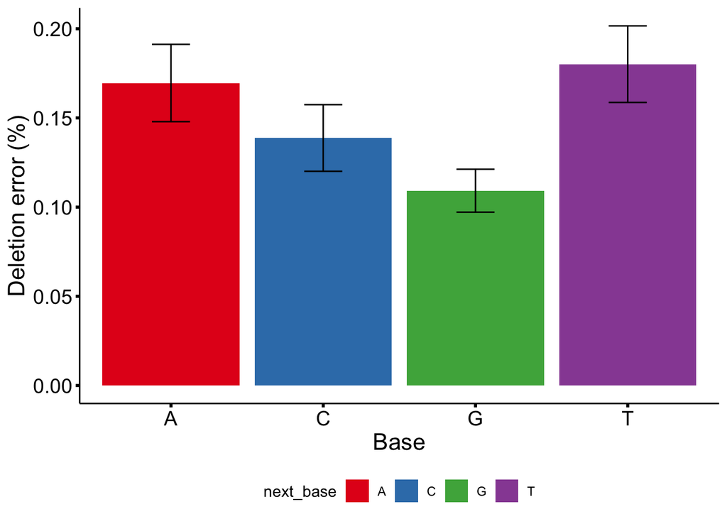

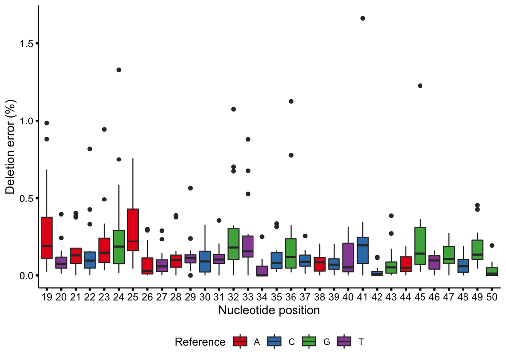

## Correlations

Are deletions and substitutions correlated with each other?

```
##
##  Spearman's rank correlation rho
##
## data:  M$Deletions and M$Substitutions
## S = 22613491, p-value = 1.726e-07
## alternative hypothesis: true rho is not equal to 0
## sample estimates:
##     rho
## 0.21906
```

Is the mean level of substitutions significantly different from SiMSen-Seq background?

```
##
##  One Sample t-test
##
## data:  M$mean
## t = 7.3648, df = 22, p-value = 2.266e-07
## alternative hypothesis: true mean is not equal to 5e-04
## 95 percent confidence interval:
##  0.03640142 0.06454585
## sample estimates:
##  mean of x
## 0.05047363
```

### Correlations by batches

```
## [1] "Substitutions_Insert_1_b1; 0.503703703703704"
## [1] "Deletions_Insert_1_b1; 0.533333333333333"
## [1] "Error_Insert_1_b1; 0.479012345679012"
## [1] "Substitutions_Insert_1_b2; 0.711111111111111"
## [1] "Deletions_Insert_1_b2; 0.644444444444444"
## [1] "Error_Insert_1_b2; 0.577777777777778"
## [1] "Substitutions_Insert_1_b3; 0.555555555555556"
## [1] "Deletions_Insert_1_b3; 0.622222222222222"
## [1] "Error_Insert_1_b3; 0.644444444444444"
## [1] "Substitutions_Insert_2_b1; 0.666666666666667"
## [1] "Deletions_Insert_2_b1; 0.666666666666667"
## [1] "Error_Insert_2_b1; 0.688888888888889"
## [1] "Substitutions_Insert_2_b2; 0.755555555555556"
## [1] "Deletions_Insert_2_b2; 0.755555555555556"
## [1] "Error_Insert_2_b2; 0.755555555555556"
## [1] "Substitutions_Insert_2_b3; 0.75"
## [1] "Deletions_Insert_2_b3; 0.85"
## [1] "Error_Insert_2_b3; 0.8"
```

### Correlations for all batches together

```r
cons.variants <- cons.table.filtered %>%
      dplyr::mutate(
            subsitution_error = 100*(A+C+G+T)/Coverage,
            indel_error = 100*(D+I)/Coverage,
            total_error =  100*(A+C+G+T+D+I)/Coverage
      ) %>%
      dplyr::filter(
        `Consensus group size` == consensus_cutoff, # Use consensus error only
        InsertType == 'Insert_1',
        Manufacturer != "control",
        Batch %in% c('b1','b2','b3')
      ) %>%
      tidyr::unite('Type', Manufacturer, Purification, Batch, sep = ' ') %>%
      dplyr::group_by(Position, Type, InsertType) %>%
      dplyr::summarise(
        Substitutions = mean(subsitution_error),
        subs_std = sd(subsitution_error),
        Deletions = mean(indel_error),
        indels_std = sd(indel_error),
        Error = mean(total_error)
      ) %>% ungroup()

# Re-order factor levels for plotting
#cons.variants$Type <- forcats::fct_relevel(cons.variants$Type, c('IDT gblocks b1', 'control MCF7'), after = Inf)

mean_errors <- cons.variants %>%
  group_by(Type) %>%
  summarise(
    mean_subs = mean(Substitutions),
    mean_dels = mean(Deletions),
    mean_total = mean(Substitutions+Deletions)
  )


print("Mean deletion error: ")
```

```
## [1] "Mean deletion error: "
```

```r
mean(mean_errors$mean_dels)
```

```
## [1] 0.1208334
```

```r
print("Mean substitution error: ")
```

```
## [1] "Mean substitution error: "
```

```r
mean(mean_errors$mean_subs)
```

```
## [1] 0.04918833
```

```r
variants <- c("Substitutions", "Deletions", "Error")

for(var in variants){
  M <- cons.variants %>%
  select(Position, Type, !!as.symbol(var)) %>%
  spread(Type, !!as.symbol(var)) %>% select(-Position)

  # Compute correlation matrix
  cor <- round(cor(M, method = "spearman"),1)
  cor[cor>=1] <- NA

  # Test for association between paired samples
  res1 <- corrplot::cor.mtest(
    mat = M,
    conf.level = .95,
    method = "spearman",
    exact = FALSE,
    alternative = "two.sided"
  )

  #print(paste(var,"_",insert,"; ", mean(cor, na.rm = TRUE), sep =""))

  # Adjust p-values for multiple testing
  pAdj <- p.adjust(c(res1[[1]]), method = "BH")
  resAdj <- matrix(pAdj, ncol = dim(res1[[1]])[1])

  colnames(resAdj) <- colnames(M)
  rownames(resAdj) <- colnames(M)

  cor_plot <- ggcorrplot::ggcorrplot(
    corr = cor,
    p.mat = resAdj,
    sig.level = 0.05,
    lab = TRUE,
    type = 'upper',
    ggtheme = theme_minimal(),
    lab_size = 2,
    show.diag = FALSE
    ) +
    scale_fill_gradient2(
      limit = c(
        min(cor, na.rm = TRUE),
        max(cor, na.rm = TRUE)
        ),
      low = viridis::viridis(100)[1],
      high =  viridis::viridis(100)[100],
      mid = viridis::viridis(100)[50],
      midpoint = mean(c(min(cor, na.rm = TRUE),max(cor, na.rm = TRUE)))
    )

  cor_plot

  #write.table(
  #  x = M,
  #  file = paste("correlation_data_",var,"_",insert,"_all-batches",".csv", sep = ""),
  #  sep = ";"
  #)

  #write.table(
  #  x = resAdj,
  #  file = paste("correlation_adjusted_p_values",var,"_",insert,"_all-batches",".csv", sep = ""),
  #  sep = ";"
  #)

  #ggplot2::ggsave(
  #  filename = paste("Figure_X_corrrelation_plot_",var,"_",insert,"_all-batches",".pdf", sep = ""),
  #  plot = cor_plot,
  #  device = 'pdf'
  #)
}
```

## Figure 2

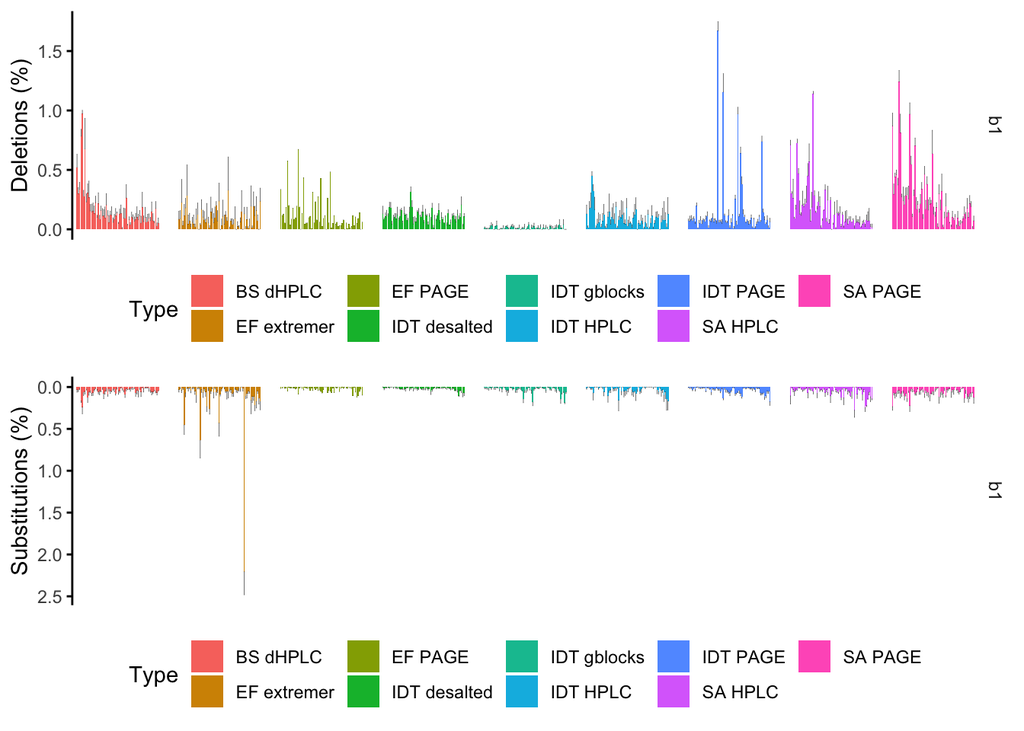

```r
figure_2 <- perBaseErrorPlot(
  data = cons.table.filtered,
  insertType = c('Insert_1', 'gDNA'),
  batch = c('b1')
)
```

```r
figure_2
```

```r
#ggsave(filename = 'Figure_2_v2.pdf', plot = figure_2, device = 'pdf')
```

```r
cons.variants <- cons.table.filtered %>%
  dplyr::mutate(
      subsitution_error = 100*(A+C+G+T)/Coverage,
      indel_error = 100*(D+I)/Coverage,
      total_error =  100*(A+C+G+T+D+I)/Coverage
  ) %>%
  dplyr::filter(
    `Consensus group size` == consensus_cutoff,
    Manufacturer %in% c('IDT', 'SA'),
    Purification %in% c('desalted', 'PAGE'),
    InsertType %in% c('Insert_1'),
    Batch %in% c('b1','b2', 'b3'),
    Position >= 19,
    Position <= 80
    ) %>%
  dplyr::group_by(Position, Manufacturer,Purification, InsertType, Batch, Reference) %>%
  dplyr::summarise(
    `Consensus 10 error (%)` = mean(total_error),
    sd = sd(total_error)
  )
```

```
## 'InsertType', 'Batch'. You can override using the `.groups` argument.
```

```r
df <- cons.variants %>% ungroup() %>%
  group_by(Manufacturer,Purification,InsertType,Batch) %>%
  summarise(
    mean_error = mean(`Consensus 10 error (%)` ),
    median_error = median(`Consensus 10 error (%)` )
    )
```

```
## 'InsertType'. You can override using the `.groups` argument.
```

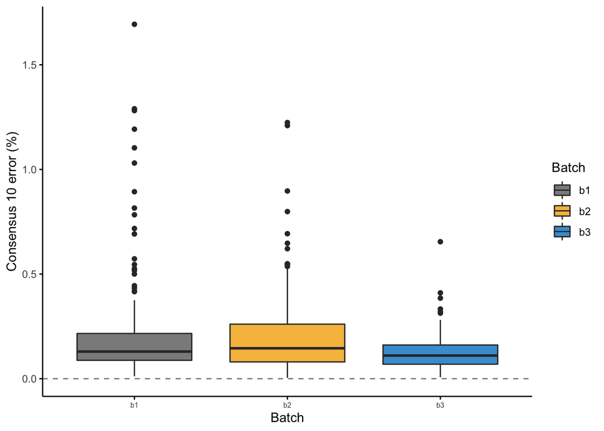

```r
plot <- ggplot(
  data = cons.variants,
  mapping = aes(x=Batch,y=`Consensus 10 error (%)` , fill = Batch)
  ) +
  geom_boxplot() + theme_classic() +
  scale_fill_manual(values=c("gray55", "#f6be4c", "#469ed4")) +
  scale_color_manual(values=c("gray55", "#f6be4c", "#469ed4")) +
  theme(
    axis.text.x = element_text(size = 6),
    panel.border = element_blank(),
    panel.grid.major = element_blank(),
    panel.grid.minor = element_blank(),
    axis.line = element_line(colour = "black"),
    axis.ticks.x = element_line(colour = "black"),
    axis.ticks.y = element_line(colour = "black")
    ) +
  geom_hline(
    yintercept = 0,
    colour="gray55",
    linetype="dashed"
  )

plot
```

```r
#df2 <- cons.variants %>% ungroup() %>% tidyr::unite('Type', Manufacturer, Purification, sep = ' ') %>%
#  dplyr::select(Position, Type,Batch, cons_error)

#res.aov2 <- aov(cons_error ~ Type + Batch, data = df2)
#summary(res.aov2)

#TukeyHSD(res.aov2, which = "Type")
#TukeyHSD(res.aov2, which = "Batch")
```

## Figure 3 barplot

```r
cons.variants <- cons.table.filtered %>%
  dplyr::mutate(
      subsitution_error = 100*(A+C+G+T)/Coverage,
      indel_error = 100*(D+I)/Coverage,
      total_error =  100*(A+C+G+T+D+I)/Coverage
  ) %>%
  dplyr::filter(
    `Consensus group size` == consensus_cutoff,
    Manufacturer %in% c('IDT', 'SA'),
    Purification %in% c('desalted', 'PAGE'),
    InsertType %in% c('Insert_1'),
    Position >= 19,
    Position <= 80
    ) %>%
  dplyr::group_by(Position, Manufacturer,Purification, InsertType, Batch, Reference) %>%
  dplyr::summarise(
    `Consensus 10 error (%)` = mean(total_error),
    sd = sd(total_error)
  )
```

```
## 'InsertType', 'Batch'. You can override using the `.groups` argument.
```

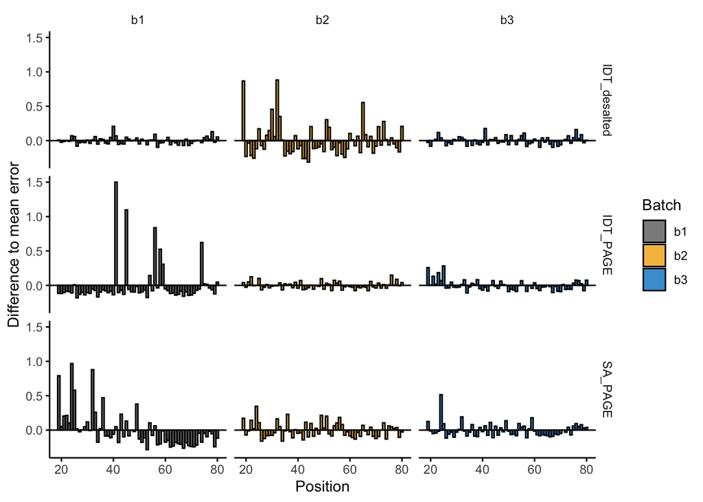

```r
consvar <- cons.variants %>% ungroup() %>%
  dplyr::mutate(Type = paste(Manufacturer,Purification, sep = '_')) %>%
  group_by(Type, Batch) %>%
  dplyr::mutate(`Difference to mean error` = `Consensus 10 error (%)` - mean(`Consensus 10 error (%)`))


# Create plot object
plot <- ggplot(
  data = consvar,
  mapping = aes(
    x = Position,
    y = `Difference to mean error`,
    fill = Batch
    )
  ) +
  geom_bar(mapping = aes(col=Batch),position="dodge", stat="identity", colour="black") +
  facet_grid(Type ~ Batch,scales = 'free_x') +
  theme_minimal() +
  scale_fill_manual(values=c("gray55", "#f6be4c", "#469ed4")) +
  scale_color_manual(values=c("gray55", "#f6be4c", "#469ed4")) +
  theme(
    axis.text.x = element_text(size = 9),
    panel.border = element_blank(),
    panel.grid.major = element_blank(),
    panel.grid.minor = element_blank(),
    axis.line = element_line(colour = "black"),
    axis.ticks.x = element_line(colour = "black"),
    axis.ticks.y = element_line(colour = "black")
    ) +  coord_cartesian(ylim = c(NA, 1.5)) +
  geom_hline(
    yintercept = 0
  )

plot
```

```r
#ggsave(
#  plot = plot,
#  filename = 'Figure_2_insert_2_alternative_v1.pdf',
#  device = 'pdf', width = 8, height = 6
#)
```

#### Outlier testing

```r
# TODO This is not used anywhere.
compute_correlation <- function(data,batch){
  corr <- data %>% ungroup() %>%
  dplyr::mutate(Type = paste(Manufacturer,Purification, sep = '_')) %>%
  group_by(Type) %>%
  select(Position, `Consensus 10 error (%)`) %>%
  filter(Type == batch) %>%
  tidyr::spread(Batch, `Consensus 10 error (%)`)

  corr <- as.data.frame(corr)
  rownames(corr) <- corr$Position
  corr$Type <- NULL
  corr$Position <- NULL

  r <- Hmisc::rcorr(as.matrix(corr), type="spearman")

  return(r)
}

df <- cons.variants %>% ungroup() %>%
  dplyr::mutate(Type = paste(Manufacturer,Purification, sep = '_')) %>%
  group_by(Type, Batch) %>%
  select(Position, `Consensus 10 error (%)`) %>%
  filter(Type == "IDT_desalted") %>%
  tidyr::spread(Batch, `Consensus 10 error (%)`)

# Perform outlier test on batch 'b1'
# TODO loop over all batches
test <- EnvStats::rosnerTest(df$b1,k = 5)

# Index for outliers in the original data set
outliers <- test$all.stats[test$all.stats$Outlier == TRUE,]$Obs.Num
```

## Ribbon plot

### Insert variant 1

**Insert variant 1.** b1, b2, b3 denote different batches. Lines show the mean error with ribbons indicating standard deviation (n = 3 technical replicates).

```r
fig <- ribbonPlot(
  data = cons.table.filtered,
  manufacturers = c("IDT", "SA"),
  purifications = c("desalted", "PAGE"),
  insertTypes = c("Insert_1"),
  start_pos = 19,
  end_pos = 80
)
```

```
## 'InsertType', 'Batch'. You can override using the `.groups` argument.
```

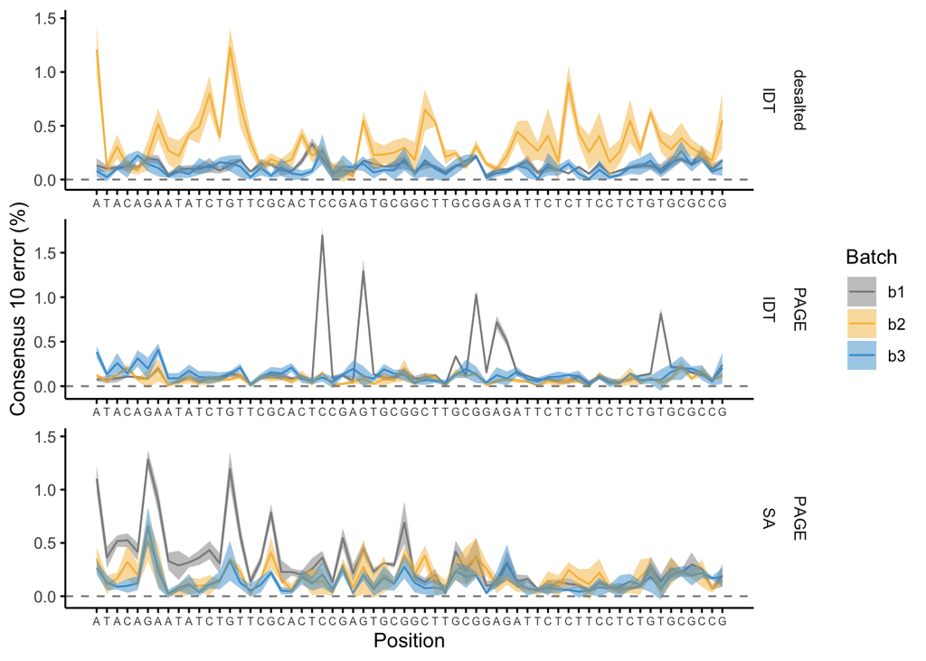

```r
fig
```

```r
#ggsave(
#  plot = fig,
#  filename = 'Figure_3.pdf',
#  device = 'pdf'
#)
```

### Insert variant 2

**Insert variant 2.** b1, b2, b3 denote different batches. Lines show the mean error with ribbons indicating standard deviation (n = 3 technical replicates).

```r
fig <- ribbonPlot(
  data = cons.table.filtered,
  manufacturers = c("IDT", "SA"),
  purifications = c("desalted", "PAGE"),
  insertTypes = c("Insert_2"),
  start_pos = 19,
  end_pos = 80
)
```

```
## 'InsertType', 'Batch'. You can override using the `.groups` argument.
```

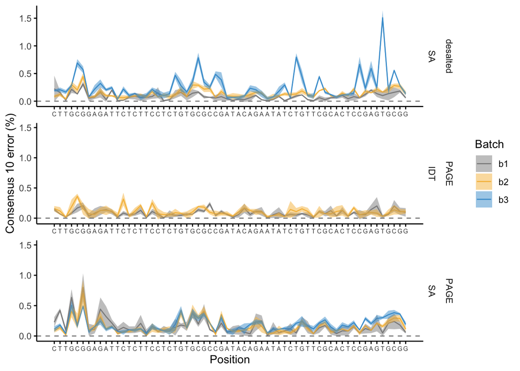

```r
fig
```

```r
#ggsave(
#  plot = amplicon_plot,
#  filename = 'Figure_4.pdf',
#  device = 'pdf'
#)
```

## Supplemental Figures

### Supplemental Fig. 1a - qPCR data

A DNA dilution series was analyzed using qPCR of the target primers of the assay used in this study. Here we plot the mean Cq values and confidence intervals.

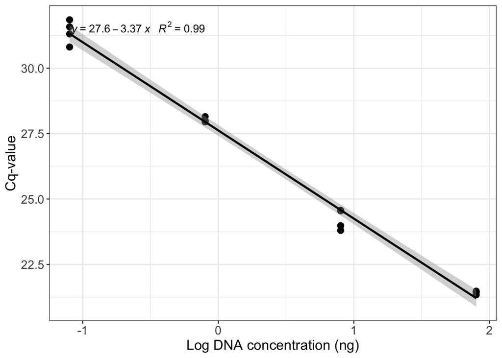

```r
# Import data
cq_values <- read.table(file = "data/cq_tp1_dilution_series.csv", sep = ",", header = TRUE)

# Reformat data for plotting
cq_values <- cq_values %>%
  tidyr::gather("Replicate", "Cq", -c("Type", "Input")) %>%
  dplyr::filter(Input != 0, Type == "MCF-7")

# Define experimental design
my.formula <- y ~ x

# Generate plot
cq_plot <- ggplot2::ggplot(
  data = cq_values,
  mapping = aes(
    x = log(Input,10),
    y = Cq
  )) +
  ggplot2::geom_point(
    aes(
      shape = Type,
      fill = "black"
    ),
    size = 3
  ) +
  theme_bw() +
  ggplot2::geom_smooth(
    method = "lm",
    formula = my.formula,
    col = "black"
  ) +
  ggpmisc::stat_poly_eq(
    formula = my.formula, col = "black",
    aes(label = paste(..eq.label.., ..rr.label.., sep = "~~~")),
    parse = TRUE
  ) +
  xlab(label = "Log DNA concentration (ng)") +
  ylab(label = "Cq-value") +
  theme(
    axis.text = element_text(size = 12),
    axis.title = element_text(size = 14),
    legend.position = "none"
  )

cq_plot
```

```r
#ggsave(
#  filename = 'Supplemental_Figure_1a.pdf',
#  plot = cq_plot,
#  device = 'pdf'
#)
```

### Supplemental Fig. 1b - Fragment Analyzer data

Here we plot an electropherogram generated using capillary gel electrophoresis of a SiMSen-Seq library generated with the assay used in this study and positive control DNA (PTC) as well as negative control (NTC), each in triplicate.

```r
# Import electropherogram data
electropherogram <- readr::read_csv(file = "data/tp1_electropherogram.csv")
```

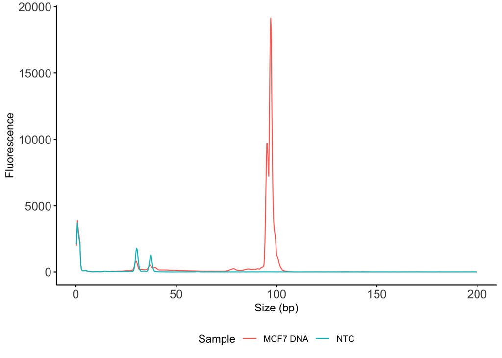

```r
# Calculate mean signal and reformat data for plotting
electropherogram <- electropherogram %>% dplyr::mutate(
    `MCF7 DNA` = rowMeans(select(electropherogram, starts_with("ptc")), na.rm = TRUE),
    NTC = rowMeans(select(electropherogram, starts_with("ntc")), na.rm = TRUE)
  ) %>%
  dplyr::select(`Size (bp)`, `MCF7 DNA`, NTC) %>%
  tidyr::gather("Sample", "Fluorescence",-c(`Size (bp)`)) %>%
  dplyr::filter(
    `Size (bp)` > 0,
    `Size (bp)` < 200
  )

# Plot electropherogram
fa_plot <- ggplot(
  data = electropherogram,
  mapping = aes(
    x = `Size (bp)`,
    y = Fluorescence
    ),
  col = Sample
  ) +
  geom_line(aes(col = Sample)) +
  theme_minimal() +
  theme(
    axis.text = element_text(size = 12),
    panel.border = element_blank(),
    panel.grid.major = element_blank(),
    panel.grid.minor = element_blank(),
    axis.line = element_line(colour = 'black'),
    axis.ticks.x = element_line(colour = 'black'),
    axis.ticks.y = element_line(colour = 'black'), legend.position = "bottom"
    )

fa_plot
```

```r
#ggsave(
#  filename = 'Supplemental_Figure_1b.pdf',
#  plot = fa_plot,
#  device = 'pdf'
#)
```

### Supplemental Fig. 1c

```r
# TODO this needs to be adapted to UMIErrorCorrect output
mean <- cons.table.filtered %>%
  dplyr::summarise(
    mean_raw = mean(rawDepth),
    mean_cons = mean(consDepth)
    )

raw_reads_mean <- mean %>% select(mean_raw)
cons_reads_mean <- mean %>% select(mean_cons)

depths <- cons.table.filtered %>%
    tidyr::unite('Type', Manufacturer, InsertType, Purification, sep = ' ') %>%
    group_by(Type, Batch, Replicate) %>%
    mutate(
        relativeRaw = rawDepth/raw_reads_mean,
        relativeCons = consDepth/cons_reads_mean
    ) %>%
  dplyr::summarise(
    rawMean = mean(relativeRaw$mean_raw),
    consMean = mean(relativeCons$mean_cons)
    ) %>%
  ungroup() %>% group_by(Type, Batch) %>%
  dplyr::summarise(
    raw = mean(rawMean),
    sd_raw = sd(rawMean),
    cons = mean(consMean),
    sd_cons = sd(consMean)
  )

# Re-level factors to move control DNA sample towards the end of the plot.
depths$Type <- forcats::fct_relevel(depths$Type, 'control Insert_1 MCF7', after = Inf)

# Plot Raw data (consensus 0)
raw_plot <- ggplot(depths, aes(x = Type, y = log2(raw), fill = Batch)) +
  geom_bar(
    stat = "identity",
    position = position_dodge(preserve = "single"),
    col = "black",
    width = 0.6
    ) +
  geom_errorbar(
    mapping = aes(ymin = log2(raw-sd_raw), ymax = log2(raw+sd_raw)),
    position = position_dodge(
      width = 0.6,
      preserve = "single"
    ),
    width = 0.25
    ) +
  ylim(-3.5,2) +
  ylab(label = "Relative raw depth (log2)") +
  scale_fill_manual(
    values = c("gray55", "#f6be4c", "#469ed4")
    ) +
  theme_minimal() +
  theme(
    axis.text.x = element_text(
      hjust = 1,
      angle = 45,
      size = 9,
      colour = "black"
    ),
    axis.text.y = element_text(
      size = 12,
      colour = "black"
    ),
    panel.border = element_blank(),
    panel.grid.major = element_blank(),
    panel.grid.minor = element_blank(),
    axis.line = element_line(colour = 'black'),
    axis.title.x = element_blank(),
    legend.position = "bottom"
    ) +
  geom_hline(
    yintercept = 0,
    colour="black"
  )

# Plot Raw data (consensus 0 and consensus 10)
cons_plot <- ggplot(depths, aes(x = Type, y = log2(cons), fill = Batch)) +
  geom_bar(
    stat = "identity",
    position = position_dodge(preserve = "single"),
    col = "black",
    width = 0.6
    ) +
  geom_errorbar(
    mapping = aes(ymin = log2(cons-sd_cons), ymax = log2(cons+sd_cons)),
    position = position_dodge(
      width = 0.6,
      preserve = "single"
    ),
    width = 0.25
    ) +
  ylim(-3.5,2) +
  ylab(label = "Relative consensus 10 depth (log2)") +
  scale_fill_manual(
    values = c("gray55", "#f6be4c", "#469ed4")
    ) +
  theme_minimal() +
  theme(
    axis.text.x = element_text(
      hjust = 1,
      angle = 45,
      size = 9,
      colour = "black"
    ),
    axis.text.y = element_text(
      size = 12,
      colour = "black"
    ),
    panel.border = element_blank(),
    panel.grid.major = element_blank(),
    panel.grid.minor = element_blank(),
    axis.line = element_line(colour = 'black'),
    axis.title.x = element_blank(),
    legend.position = "bottom"
    ) +
  geom_hline(
    yintercept = 0,
    colour="black"
  )

supp_figure_1 <- raw_plot + cons_plot
supp_figure_1

#ggsave(
#  filename = 'Supplemental_Figure_1.pdf',
#  plot = supp_figure_1,
#  device = 'pdf',
#  width = 12,
#  height = 4
#)
```

## Supplemental Figure 2

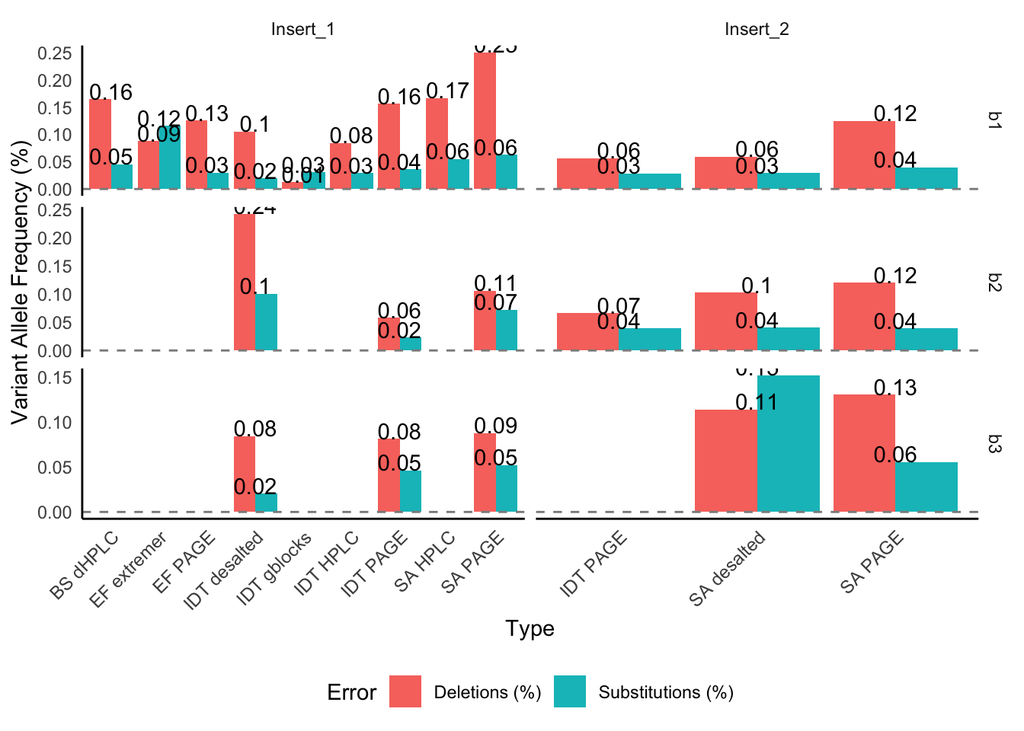

### Supplemental Figure 3 - Error plot insert variant 1

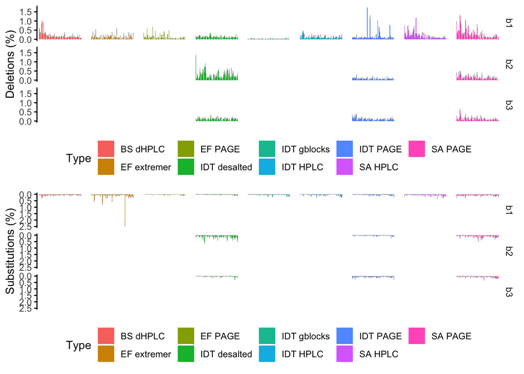

### Supplemental Figure 4 - Error plot insert variant 2

Plot substitution and indel errors for all batches of insert variant 2.

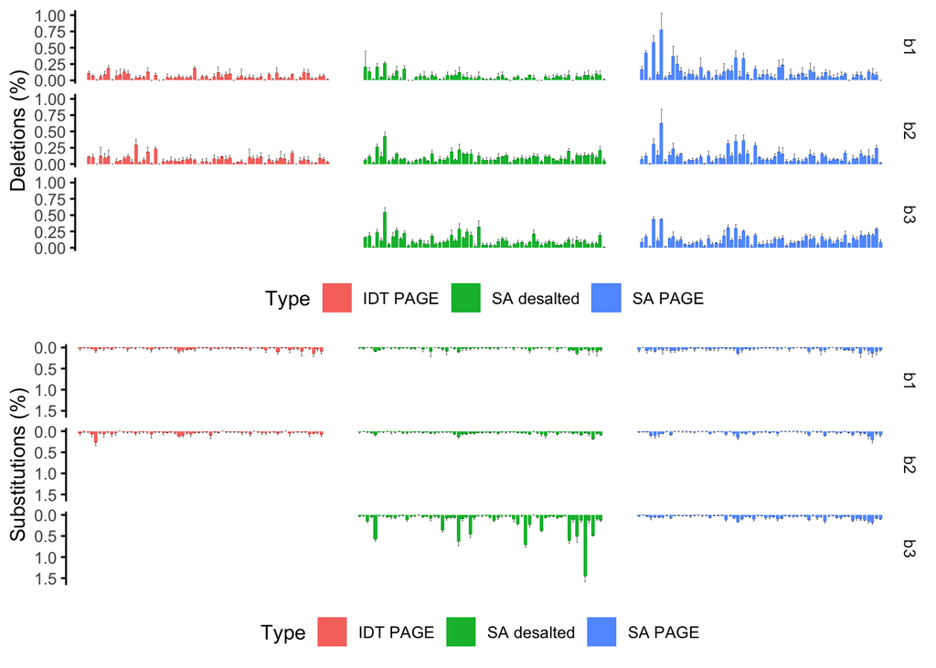

## System information

This analysis was performed with the following system specifications: